# Zotero group VA

Published

16 October 2026

Zotero data of 16 October 2026 · IPBES Literature Report 0.4.0 · [source code on GitHub](https://github.com/IPBES-Data/IPBES.LiteratureReport)

This report shows the state of the Zotero group **VA** ([open the group in Zotero](https://www.zotero.org/groups/2345372)). It gives an overview of the literature in the group, and lists the items which should be corrected.

Each item in the lists can be opened in the Zotero **web** library or in the Zotero **app** on your computer, so that it can be corrected directly. Corrected items disappear from the lists the next time the report is updated. Some checks compare the items with [OpenAlex](https://openalex.org), an open catalogue of scholarly publications.

## Summary

| Status | Check | Items |
| --- | --- | --- |
| ● OK | Retracted publications | 0 |
| ● Please fix | DOI points to a different publication | 167 |
| ● Please fix | Items which are in the group more than once | 187 |
| ● Please fix | DOI field with an invalid DOI | 3 |
| ● Please fix | DOI field with a link or prefix instead of the DOI | 20 |
| ● Please check | ISSN not in the standard form | 761 |
| ● Please check | DOI in the wrong field | 19 |
| ● Please check | DOI not found in OpenAlex | 23 |
| ● Please check | Missing or unusual publication year | 25 |
| ● Please check | Empty journal, volume, issue or pages, found in OpenAlex | 102 |
| ● Please check | Language not given as a language code | 257 |
| ● Please check | Items without DOI, ISBN, ISSN or URL | 326 |
| ● Please check | Items without DOI, for which OpenAlex has one | 343 |
| ● OK | OpenAlex ID in Extra not valid | 0 |
| ● For information | Items without their OpenAlex ID in Extra | 1991 |
| ● OK | Items without tags | 0 |

**Please fix**: these items contain errors. **Please check**: these items may need a correction. **For information**: no action needed unless the group uses this, e.g. tags.

## Items to fix

The lists are sorted by importance. Use the search field above a list to find an item. **web** opens the item in the Zotero web library, **app** in the Zotero app.

### Retracted publications

These publications have been retracted. Check whether they should still be cited, and mark or remove them in Zotero.

**✔ Nothing to fix.**

### DOI points to a different publication

The DOI of these items leads to a publication with a different title or year. Usually the DOI is wrong: open the DOI to see where it leads, and correct it in Zotero. Differences of one year (e.g. published online before print) are not listed.

| Open in Zotero | Title in Zotero | Year in Zotero | The DOI leads to | Its year | DOI |
| --- | --- | --- | --- | --- | --- |
| <a href="https://www.zotero.org/groups/2345372/items/8WYLUFSZ" target="_blank">web</a> &middot; <a href="zotero://select/groups/2345372/items/8WYLUFSZ">app</a> | Spatial patterns of carbon, biodiversity, deforestation threat, and REDD+ projects in Indonesia: The delivery of biodiversity benefits in REDD+ | 2015 | Spatial patterns of carbon, biodiversity, deforestation threat, and REDD+ projects in Indonesia | 2015 | <a href="https://doi.org/10.1111/cobi.12500" target="_blank">10.1111/cobi.12500</a> |
| <a href="https://www.zotero.org/groups/2345372/items/FBB8FMYV" target="_blank">web</a> &middot; <a href="zotero://select/groups/2345372/items/FBB8FMYV">app</a> | Suma qamaña in Bolivia: Indigenous Understandings of Well-being and Their Contribution to a Post-Neoliberal Paradigm | 2015 | Suma qamaña in Bolivia | 2014 | <a href="https://doi.org/10.1177/0094582x14547501" target="_blank">10.1177/0094582x14547501</a> |
| <a href="https://www.zotero.org/groups/2345372/items/YNP58SE7" target="_blank">web</a> &middot; <a href="zotero://select/groups/2345372/items/YNP58SE7">app</a> | Human Activity and the Environment | 2017 | Human Activity and the Environment | 1978 | <a href="https://doi.org/10.2307/3549992" target="_blank">10.2307/3549992</a> |
| <a href="https://www.zotero.org/groups/2345372/items/UFY6HYYV" target="_blank">web</a> &middot; <a href="zotero://select/groups/2345372/items/UFY6HYYV">app</a> | GRASP agents: social first, intelligent later | 2019 | GRASP agents: social first, intelligent later | 2017 | <a href="https://doi.org/10.1007/s00146-017-0783-7" target="_blank">10.1007/s00146-017-0783-7</a> |
| <a href="https://www.zotero.org/groups/2345372/items/WKD4BUK4" target="_blank">web</a> &middot; <a href="zotero://select/groups/2345372/items/WKD4BUK4">app</a> | Forest conservation policy and motivational crowding: Experimental evidence from Tanzania | 2019 | Forest conservation policy and motivational crowding: Experimental evidence from Tanzania | 2016 | <a href="https://doi.org/10.1016/j.ecolecon.2016.07.002" target="_blank">10.1016/j.ecolecon.2016.07.002</a> |
| <a href="https://www.zotero.org/groups/2345372/items/9AT9WGXU" target="_blank">web</a> &middot; <a href="zotero://select/groups/2345372/items/9AT9WGXU">app</a> | Conserving Biodiversity Through Certification of Tropical Agroforestry Crops at Local and Landscape Scales: Conserving biodiversity by crop certification | 2015 | Conserving Biodiversity Through Certification of Tropical Agroforestry Crops at Local and Landscape Scales | 2014 | <a href="https://doi.org/10.1111/conl.12110" target="_blank">10.1111/conl.12110</a> |
| <a href="https://www.zotero.org/groups/2345372/items/3S5D42PJ" target="_blank">web</a> &middot; <a href="zotero://select/groups/2345372/items/3S5D42PJ">app</a> | The decision to use benefit transfer or conduct original valuation | 2008 | THE DECISION TO USE BENEFIT TRANSFER OR CONDUCT ORIGINAL VALUATION RESEARCH FOR BENEFIT‐COST AND POLICY ANALYSIS | 2007 | <a href="https://doi.org/10.1111/j.1465-7287.2007.00066.x" target="_blank">10.1111/j.1465-7287.2007.00066.x</a> |
| <a href="https://www.zotero.org/groups/2345372/items/VHGUN3UG" target="_blank">web</a> &middot; <a href="zotero://select/groups/2345372/items/VHGUN3UG">app</a> | Collaborative Governance for Climate Change Adaptation: Mapping citizen-municipality interactions: Collaborative governance for climate change adaptation | 2018 | Collaborative Governance for Climate Change Adaptation: Mapping citizen–municipality interactions | 2017 | <a href="https://doi.org/10.1002/eet.1795" target="_blank">10.1002/eet.1795</a> |
| <a href="https://www.zotero.org/groups/2345372/items/Z5FNKYYM" target="_blank">web</a> &middot; <a href="zotero://select/groups/2345372/items/Z5FNKYYM">app</a> | A characterization of media representation of biodiversity and implications for public perceptions and environmental policy: the case of Québec, Canada | 2020 | A characterization of media representation of biodiversity and implications for public perceptions and environmental policy: the case of Québec, Canada | 2018 | <a href="https://doi.org/10.1007/s10668-018-0244-6" target="_blank">10.1007/s10668-018-0244-6</a> |
| <a href="https://www.zotero.org/groups/2345372/items/YT8FQVHM" target="_blank">web</a> &middot; <a href="zotero://select/groups/2345372/items/YT8FQVHM">app</a> | Sociocultural Variables That Impact High School Students’ Perceptions of Native Fauna: a Study on the Species Component of the Biodiversity Concept | 2017 | Sociocultural Variables That Impact High School Students’ Perceptions of Native Fauna: a Study on the Species Component of the Biodiversity Concept | 2015 | <a href="https://doi.org/10.1007/s11165-015-9496-4" target="_blank">10.1007/s11165-015-9496-4</a> |

[output cut: 157 more lines]

### Items which are in the group more than once

These items are in the group more than once, with the same DOI, or with the same title, year and first author. Keep one copy and merge or delete the others, e.g. with *Duplicate Items* in the Zotero app.

| Open in Zotero | Title | Copies |
| --- | --- | --- |
| <a href="https://www.zotero.org/groups/2345372/items/228DNARQ" target="_blank">web</a> &middot; <a href="zotero://select/groups/2345372/items/228DNARQ">app</a><br><a href="https://www.zotero.org/group… | Valuing non-market economic impacts from natural hazards | 3 |
| <a href="https://www.zotero.org/groups/2345372/items/FL4CPHL5" target="_blank">web</a> &middot; <a href="zotero://select/groups/2345372/items/FL4CPHL5">app</a><br><a href="https://www.zotero.org/group… | Coming Full Circle: Indigenous Knowledge, Environment, and Our Future | 2 |
| <a href="https://www.zotero.org/groups/2345372/items/YM7VRUFJ" target="_blank">web</a> &middot; <a href="zotero://select/groups/2345372/items/YM7VRUFJ">app</a><br><a href="https://www.zotero.org/group… | Contingent Valuation: From Dubious to Hopeless | 3 |
| <a href="https://www.zotero.org/groups/2345372/items/AM3PW25K" target="_blank">web</a> &middot; <a href="zotero://select/groups/2345372/items/AM3PW25K">app</a><br><a href="https://www.zotero.org/group… | The maturation of ecosystem services: Social and policy research expands, but whither biophysically informed valuation? | 3 |
| <a href="https://www.zotero.org/groups/2345372/items/TMGYTY7U" target="_blank">web</a> &middot; <a href="zotero://select/groups/2345372/items/TMGYTY7U">app</a><br><a href="https://www.zotero.org/group… | Key issues and priorities in participatory mapping: Toward integration or increased specialization? | 2 |
| <a href="https://www.zotero.org/groups/2345372/items/E34HEENM" target="_blank">web</a> &middot; <a href="zotero://select/groups/2345372/items/E34HEENM">app</a><br><a href="https://www.zotero.org/group… | Look at me Saving the Planet! The Imitation of Visible Green Behavior and its Impact on the Climate Value-Action Gap | 2 |
| <a href="https://www.zotero.org/groups/2345372/items/KFFGHP5H" target="_blank">web</a> &middot; <a href="zotero://select/groups/2345372/items/KFFGHP5H">app</a><br><a href="https://www.zotero.org/group… | From Environmental Connectedness to Sustainable Futures: Topophilia and Human Affiliation with Nature | 2 |
| <a href="https://www.zotero.org/groups/2345372/items/5FCE2T8Y" target="_blank">web</a> &middot; <a href="zotero://select/groups/2345372/items/5FCE2T8Y">app</a><br><a href="https://www.zotero.org/group… | Suma Qamaña or Living Well Together: A Contribution to Biocultural Conservation | 3 |
| <a href="https://www.zotero.org/groups/2345372/items/KTNQPZQF" target="_blank">web</a> &middot; <a href="zotero://select/groups/2345372/items/KTNQPZQF">app</a><br><a href="https://www.zotero.org/group… | A comparative assessment of decision support tools for ecosystem services quantification and valuation | 3 |
| <a href="https://www.zotero.org/groups/2345372/items/HTTWHPWZ" target="_blank">web</a> &middot; <a href="zotero://select/groups/2345372/items/HTTWHPWZ">app</a><br><a href="https://www.zotero.org/group… | An empirical review of cultural ecosystem service indicators | 2 |

[output cut: 150 more lines]

### DOI field with an invalid DOI

The DOI field of these items contains something which is not a valid DOI. Correct or remove it.

| Open in Zotero | Title | Content of the DOI field |
| --- | --- | --- |
| <a href="https://www.zotero.org/groups/2345372/items/98M2ERGI" target="_blank">web</a> &middot; <a href="zotero://select/groups/2345372/items/98M2ERGI">app</a> | Going beyond panaceas | 10.1073pnas.0701886104 |
| <a href="https://www.zotero.org/groups/2345372/items/6L378E8K" target="_blank">web</a> &middot; <a href="zotero://select/groups/2345372/items/6L378E8K">app</a> | Natural Capital Accounting. Overview and Progress in the European Union | 10. 2779/819449 |
| <a href="https://www.zotero.org/groups/2345372/items/JZP853TQ" target="_blank">web</a> &middot; <a href="zotero://select/groups/2345372/items/JZP853TQ">app</a> | Making intercultural language learning visible and assessable | http://cercll.arizona.edu/ICConference2010 |

### DOI field with a link or prefix instead of the DOI

The DOI field of these items contains the DOI as a link (`https://doi.org/…`) or with a prefix (`DOI …`). Citation styles add the link themselves, so it would appear twice. Replace it with the DOI only.

| Open in Zotero | Title | Content of the DOI field | DOI |
| --- | --- | --- | --- |
| <a href="https://www.zotero.org/groups/2345372/items/KTNQPZQF" target="_blank">web</a> &middot; <a href="zotero://select/groups/2345372/items/KTNQPZQF">app</a> | A comparative assessment of decision support tools for ecosystem services quantification and valuation | http://dx.doi.org/10.1016/j.ecoser.2013.07.004 | <a href="https://doi.org/10.1016/j.ecoser.2013.07.004" target="_blank">10.1016/j.ecoser.2013.07.004</a> |
| <a href="https://www.zotero.org/groups/2345372/items/SKU87E95" target="_blank">web</a> &middot; <a href="zotero://select/groups/2345372/items/SKU87E95">app</a> | Monetary valuation of ecosystem services: It matters to get the timeline right | http://dx.doi.org/10.1016/j.ecolecon.2013.09.009 | <a href="https://doi.org/10.1016/j.ecolecon.2013.09.009" target="_blank">10.1016/j.ecolecon.2013.09.009</a> |
| <a href="https://www.zotero.org/groups/2345372/items/KHPTMMBS" target="_blank">web</a> &middot; <a href="zotero://select/groups/2345372/items/KHPTMMBS">app</a> | Rights of nature and the indigenous peoples in Bolivia and Ecuador: A straitjacket for progressive development politics? | http://dx.doi.org/10.2139/ssrn.2554291 | <a href="https://doi.org/10.2139/ssrn.2554291" target="_blank">10.2139/ssrn.2554291</a> |
| <a href="https://www.zotero.org/groups/2345372/items/RVD4AWR2" target="_blank">web</a> &middot; <a href="zotero://select/groups/2345372/items/RVD4AWR2">app</a> | Integrating Ecological Indicators into Federal-State Fiscal Relations: A policy design study for Germany | https://doi.org/10.1002/eet.1774 | <a href="https://doi.org/10.1002/eet.1774" target="_blank">10.1002/eet.1774</a> |
| <a href="https://www.zotero.org/groups/2345372/items/2SDGQMK4" target="_blank">web</a> &middot; <a href="zotero://select/groups/2345372/items/2SDGQMK4">app</a> | Stewardship of Natural Resources: Definition, Ethical and Practical Aspects | doi.org/10.1023/A:1009534214698 | <a href="https://doi.org/10.1023/A:1009534214698" target="_blank">10.1023/A:1009534214698</a> |
| <a href="https://www.zotero.org/groups/2345372/items/9H9XPUE7" target="_blank">web</a> &middot; <a href="zotero://select/groups/2345372/items/9H9XPUE7">app</a> | Indigenous Beliefs and Environmental Stewardship: A Rural Ghana Experience | doi.org/10.1080/08873630709478212 | <a href="https://doi.org/10.1080/08873630709478212" target="_blank">10.1080/08873630709478212</a> |
| <a href="https://www.zotero.org/groups/2345372/items/628FGDJG" target="_blank">web</a> &middot; <a href="zotero://select/groups/2345372/items/628FGDJG">app</a> | Environmental Goods and the Distribution of Income | DOI https://doi.org/10.1023/A:1025052225929 | <a href="https://doi.org/10.1023/A:1025052225929" target="_blank">10.1023/A:1025052225929</a> |
| <a href="https://www.zotero.org/groups/2345372/items/MEIM936D" target="_blank">web</a> &middot; <a href="zotero://select/groups/2345372/items/MEIM936D">app</a> | À propos des relations natures/sociétés − The shift toward social-ecological systems perspectives: insights into the human-nature relationship | DOI: 10.1051/nss/2015034 | <a href="https://doi.org/10.1051/nss/2015034" target="_blank">10.1051/nss/2015034</a> |
| <a href="https://www.zotero.org/groups/2345372/items/KHGYNHNP" target="_blank">web</a> &middot; <a href="zotero://select/groups/2345372/items/KHGYNHNP">app</a> | Learning Lessons from Disasters: Alternatives to Royal Commissions and Other Quasi-Judicial Inquiries | https://doi.org/10.1111/1467-8500.12115 | <a href="https://doi.org/10.1111/1467-8500.12115" target="_blank">10.1111/1467-8500.12115</a> |
| <a href="https://www.zotero.org/groups/2345372/items/TSIB2IUY" target="_blank">web</a> &middot; <a href="zotero://select/groups/2345372/items/TSIB2IUY">app</a> | Stakeholders’ perspectives on the operationalisation of the ecosystem service concept: Results from 27 case studies | https://doi.org/10.1016/j.ecoser.2017.09.015 | <a href="https://doi.org/10.1016/j.ecoser.2017.09.015" target="_blank">10.1016/j.ecoser.2017.09.015</a> |

[output cut: 10 more lines]

### ISSN not in the standard form

The ISSN field of these items is not in the standard form `1234-567X` (several separated by “,”), or contains something which is not a valid ISSN, e.g. an ISBN.

| Open in Zotero | Title | Content of the ISSN field | Standard form | Not a valid ISSN |
| --- | --- | --- | --- | --- |
| <a href="https://www.zotero.org/groups/2345372/items/XJNUBFKW" target="_blank">web</a> &middot; <a href="zotero://select/groups/2345372/items/XJNUBFKW">app</a> | A look in the mirror: reflection on participation in Integrated Assessment from a methodological perspective | 09593780 | 0959-3780 | NA |
| <a href="https://www.zotero.org/groups/2345372/items/AM3PW25K" target="_blank">web</a> &middot; <a href="zotero://select/groups/2345372/items/AM3PW25K">app</a> | The maturation of ecosystem services: Social and policy research expands, but whither biophysically informed valuation? | 2575-8314, 2575-8314 | 2575-8314 | NA |
| <a href="https://www.zotero.org/groups/2345372/items/TMGYTY7U" target="_blank">web</a> &middot; <a href="zotero://select/groups/2345372/items/TMGYTY7U">app</a> | Key issues and priorities in participatory mapping: Toward integration or increased specialization? | 01436228 | 0143-6228 | NA |
| <a href="https://www.zotero.org/groups/2345372/items/E34HEENM" target="_blank">web</a> &middot; <a href="zotero://select/groups/2345372/items/E34HEENM">app</a> | Look at me Saving the Planet! The Imitation of Visible Green Behavior and its Impact on the Climate Value-Action Gap | 09218009 | 0921-8009 | NA |
| <a href="https://www.zotero.org/groups/2345372/items/G3358VY3" target="_blank">web</a> &middot; <a href="zotero://select/groups/2345372/items/G3358VY3">app</a> | Look at me Saving the Planet! The Imitation of Visible Green Behavior and its Impact on the Climate Value-Action Gap | 09218009 | 0921-8009 | NA |
| <a href="https://www.zotero.org/groups/2345372/items/SWC9NHP2" target="_blank">web</a> &middot; <a href="zotero://select/groups/2345372/items/SWC9NHP2">app</a> | A comparative assessment of decision-support tools for ecosystem services quantification and valuation | 22120416 | 2212-0416 | NA |
| <a href="https://www.zotero.org/groups/2345372/items/HTTWHPWZ" target="_blank">web</a> &middot; <a href="zotero://select/groups/2345372/items/HTTWHPWZ">app</a> | An empirical review of cultural ecosystem service indicators | 1470160X | 1470-160X | NA |
| <a href="https://www.zotero.org/groups/2345372/items/YIZMVLD9" target="_blank">web</a> &middot; <a href="zotero://select/groups/2345372/items/YIZMVLD9">app</a> | Risk assessment and risk management: Review of recent advances on their foundation | 03772217 | 0377-2217 | NA |
| <a href="https://www.zotero.org/groups/2345372/items/G6USSA3L" target="_blank">web</a> &middot; <a href="zotero://select/groups/2345372/items/G6USSA3L">app</a> | A comparative assessment of decision-support tools for ecosystem services quantification and valuation | 22120416 | 2212-0416 | NA |
| <a href="https://www.zotero.org/groups/2345372/items/2JGBGBFQ" target="_blank">web</a> &middot; <a href="zotero://select/groups/2345372/items/2JGBGBFQ">app</a> | Perceptions of the ecosystem services concept: Opportunities and challenges in the Swedish municipal context | 22120416 | 2212-0416 | NA |

[output cut: 751 more lines]

### DOI in the wrong field

These items have no DOI in the DOI field, but a DOI in the URL or Extra field. Copy the DOI into the DOI field.

| Open in Zotero | Title | DOI in URL | DOI in Extra |
| --- | --- | --- | --- |
| <a href="https://www.zotero.org/groups/2345372/items/YD6CLJFZ" target="_blank">web</a> &middot; <a href="zotero://select/groups/2345372/items/YD6CLJFZ">app</a> | Rio de Janeiro: A State in Socio-ecological Transformation | <a href="https://doi.org/10.1007/978-3-319-89644-1_1" target="_blank">10.1007/978-3-319-89644-1_1</a> |  |
| <a href="https://www.zotero.org/groups/2345372/items/4PVA5IFC" target="_blank">web</a> &middot; <a href="zotero://select/groups/2345372/items/4PVA5IFC">app</a> | Participatory Capacity and Vulnerability Analysis (PVCA) toolkit.pdf | <a href="https://doi.org/10.13140/rg.2.2.13762.17603" target="_blank">10.13140/rg.2.2.13762.17603</a> |  |
| <a href="https://www.zotero.org/groups/2345372/items/GDGIFGC5" target="_blank">web</a> &middot; <a href="zotero://select/groups/2345372/items/GDGIFGC5">app</a> | How multiple values influence decisions on sustainable use in socio-ecological production landscapes and seascapes (SEPLS) | <a href="https://doi.org/10.13140/rg.2.2.11723.34087" target="_blank">10.13140/rg.2.2.11723.34087</a> |  |
| <a href="https://www.zotero.org/groups/2345372/items/2JJFU5RQ" target="_blank">web</a> &middot; <a href="zotero://select/groups/2345372/items/2JJFU5RQ">app</a> | UNESCO Biosphere Reserves Supporting Biocultural Diversity, Sustainability and Society | <a href="https://doi.org/10.1080/08941920.2020.1734703" target="_blank">10.1080/08941920.2020.1734703</a> |  |
| <a href="https://www.zotero.org/groups/2345372/items/Y95U3H6S" target="_blank">web</a> &middot; <a href="zotero://select/groups/2345372/items/Y95U3H6S">app</a> | Evaluating Projects and Assessing Sustainable Development in Imperfect Economies | <a href="https://doi.org/10.1023/b:eare.0000007353.78828.98.pdf" target="_blank">10.1023/b:eare.0000007353.78828.98.pdf</a> |  |
| <a href="https://www.zotero.org/groups/2345372/items/KAMRPBDW" target="_blank">web</a> &middot; <a href="zotero://select/groups/2345372/items/KAMRPBDW">app</a> | Social learning and sustainable development | <a href="https://doi.org/10.1038/nclimate2080" target="_blank">10.1038/nclimate2080</a> |  |
| <a href="https://www.zotero.org/groups/2345372/items/WBI2HN3M" target="_blank">web</a> &middot; <a href="zotero://select/groups/2345372/items/WBI2HN3M">app</a> | Awareness as the new paradigm for personal sustainability A practitioner’s perspective on the sustainability transition | <a href="https://doi.org/10.4324/9781315159997-9" target="_blank">10.4324/9781315159997-9</a> |  |
| <a href="https://www.zotero.org/groups/2345372/items/NZ955M77" target="_blank">web</a> &middot; <a href="zotero://select/groups/2345372/items/NZ955M77">app</a> | Sustainability Impact Assessment of a Certification Scheme in the Indonesian Cocoa Industry: 2012 Pilot Survey Results | <a href="https://doi.org/10.13140/rg.2.1.3370.2804" target="_blank">10.13140/rg.2.1.3370.2804</a> |  |
| <a href="https://www.zotero.org/groups/2345372/items/FFCUFN3S" target="_blank">web</a> &middot; <a href="zotero://select/groups/2345372/items/FFCUFN3S">app</a> | Accounting for ecosystems and their services in the European Union (INCA): final report from phase II of the INCA project aiming to develop a pilot for an integrated system of ecosystem accounts for t… | <a href="https://doi.org/10.2785/197909" target="_blank">10.2785/197909</a> |  |
| <a href="https://www.zotero.org/groups/2345372/items/CHW85K7W" target="_blank">web</a> &middot; <a href="zotero://select/groups/2345372/items/CHW85K7W">app</a> | Mapping and assessment of ecosystems and their services: an EU wide ecosystem assessment in support of the EU biodiversity strategy. | <a href="https://doi.org/10.2760/757183" target="_blank">10.2760/757183</a> |  |

[output cut: 9 more lines]

### DOI not found in OpenAlex

These DOIs were not found in OpenAlex. The DOI may be wrong: open it to check. If it leads to the right publication, the publication is simply not (yet) in OpenAlex and nothing needs to be done.

| Open in Zotero | Title | DOI |
| --- | --- | --- |
| <a href="https://www.zotero.org/groups/2345372/items/S97EGG9W" target="_blank">web</a> &middot; <a href="zotero://select/groups/2345372/items/S97EGG9W">app</a> | Borneo Futures, Bandar Seri Begawan, Brunei Darussalam | <a href="https://doi.org/10.13140/rg.2.2.35387.21287" target="_blank">10.13140/rg.2.2.35387.21287</a> |
| <a href="https://www.zotero.org/groups/2345372/items/MV48DH3L" target="_blank">web</a> &middot; <a href="zotero://select/groups/2345372/items/MV48DH3L">app</a> | Learning to listen: snapshots of Aboriginal participation in environmental assessment | <a href="https://doi.org/10.13140/rg.2.1.4176.7921" target="_blank">10.13140/rg.2.1.4176.7921</a> |
| <a href="https://www.zotero.org/groups/2345372/items/KHPTMMBS" target="_blank">web</a> &middot; <a href="zotero://select/groups/2345372/items/KHPTMMBS">app</a> | Rights of nature and the indigenous peoples in Bolivia and Ecuador: A straitjacket for progressive development politics? | <a href="https://doi.org/10.2139/ssrn.2554291" target="_blank">10.2139/ssrn.2554291</a> |
| <a href="https://www.zotero.org/groups/2345372/items/K2Y49EUP" target="_blank">web</a> &middot; <a href="zotero://select/groups/2345372/items/K2Y49EUP">app</a> | Workshop Report on Biodiversity and Pandemics of the Intergovernmental Platform on Biodiversity and Ecosystem Services | <a href="https://doi.org/10.5281/zenodo.4147317" target="_blank">10.5281/zenodo.4147317</a> |
| <a href="https://www.zotero.org/groups/2345372/items/HLFL5IJ6" target="_blank">web</a> &middot; <a href="zotero://select/groups/2345372/items/HLFL5IJ6">app</a> | Beyond harvests in the commons: multi-scale governance and turbulence in indigenous/community conserved areas in Oaxaca, Mexico | <a href="https://doi.org/10.18352/ijc.328" target="_blank">10.18352/ijc.328</a> |
| <a href="https://www.zotero.org/groups/2345372/items/G34757SB" target="_blank">web</a> &middot; <a href="zotero://select/groups/2345372/items/G34757SB">app</a> | Rwanda natural capital accounts - Ecosystems | <a href="https://doi.org/10.13140/rg.2.2.23507.32806" target="_blank">10.13140/rg.2.2.23507.32806</a> |
| <a href="https://www.zotero.org/groups/2345372/items/HA9DGUPG" target="_blank">web</a> &middot; <a href="zotero://select/groups/2345372/items/HA9DGUPG">app</a> | Beyond a Market Discourse: Is Framing a Solution to Avoid Motivational Crowding-Out in Payments for Ecosystem Services? | <a href="https://doi.org/10.2139/ssrn.3910112" target="_blank">10.2139/ssrn.3910112</a> |
| <a href="https://www.zotero.org/groups/2345372/items/F89LL7H3" target="_blank">web</a> &middot; <a href="zotero://select/groups/2345372/items/F89LL7H3">app</a> | Part 2. The SDG Index and Dashboards | <a href="https://doi.org/10.1017/97811089922411" target="_blank">10.1017/97811089922411</a> |
| <a href="https://www.zotero.org/groups/2345372/items/UDNLCDEP" target="_blank">web</a> &middot; <a href="zotero://select/groups/2345372/items/UDNLCDEP">app</a> | Mediation and conservation conflicts: From top-down to bottom-up | <a href="https://doi.org/10.1017/9781139084574.017" target="_blank">10.1017/9781139084574.017</a> |
| <a href="https://www.zotero.org/groups/2345372/items/IMBA7DGH" target="_blank">web</a> &middot; <a href="zotero://select/groups/2345372/items/IMBA7DGH">app</a> | Environmental Values and Adaptive Management | <a href="https://doi.org/10.3197/096327101129340921" target="_blank">10.3197/096327101129340921</a> |

[output cut: 13 more lines]

### Missing or unusual publication year

These items have no date, a date from which no year could be read, or a year in the future. Correct the date in Zotero.

| Open in Zotero | Title | Date | Problem | Date in OpenAlex |
| --- | --- | --- | --- | --- |
| <a href="https://www.zotero.org/groups/2345372/items/C2ZQW9TG" target="_blank">web</a> &middot; <a href="zotero://select/groups/2345372/items/C2ZQW9TG">app</a> | Who gets to imagine transformative change? Participation and representation in biodiversity assessments | undefined/ed | Year not recognised | NA |
| <a href="https://www.zotero.org/groups/2345372/items/YD6CLJFZ" target="_blank">web</a> &middot; <a href="zotero://select/groups/2345372/items/YD6CLJFZ">app</a> | Rio de Janeiro: A State in Socio-ecological Transformation | 2019b | Year not recognised | NA |
| <a href="https://www.zotero.org/groups/2345372/items/T5B9TAT7" target="_blank">web</a> &middot; <a href="zotero://select/groups/2345372/items/T5B9TAT7">app</a> | Towards a post-2020 common agricultural policy | 2020b | Year not recognised | NA |
| <a href="https://www.zotero.org/groups/2345372/items/GMZLRRXS" target="_blank">web</a> &middot; <a href="zotero://select/groups/2345372/items/GMZLRRXS">app</a> | How the future CAP will contribute to the EU Green Deal | 2020a | Year not recognised | NA |
| <a href="https://www.zotero.org/groups/2345372/items/Q4MBQ3Z3" target="_blank">web</a> &middot; <a href="zotero://select/groups/2345372/items/Q4MBQ3Z3">app</a> | Storage and Disposal Options for Radioactive Waste | 2020b | Year not recognised | NA |
| <a href="https://www.zotero.org/groups/2345372/items/JJZ77LF4" target="_blank">web</a> &middot; <a href="zotero://select/groups/2345372/items/JJZ77LF4">app</a> | Radioactive Waste Management | 2020a | Year not recognised | NA |
| <a href="https://www.zotero.org/groups/2345372/items/S3MKUC4L" target="_blank">web</a> &middot; <a href="zotero://select/groups/2345372/items/S3MKUC4L">app</a> | Moving towards partnership: triennial report 2017 to 2019 | 2020b | Year not recognised | NA |
| <a href="https://www.zotero.org/groups/2345372/items/6QEXNDZN" target="_blank">web</a> &middot; <a href="zotero://select/groups/2345372/items/6QEXNDZN">app</a> | Implementing Adaptive Phased Management 2020 to 2024 | 2020a | Year not recognised | NA |
| <a href="https://www.zotero.org/groups/2345372/items/5J595ZLL" target="_blank">web</a> &middot; <a href="zotero://select/groups/2345372/items/5J595ZLL">app</a> | ValuES - About the Project |  | No date | NA |
| <a href="https://www.zotero.org/groups/2345372/items/RKS5DJC5" target="_blank">web</a> &middot; <a href="zotero://select/groups/2345372/items/RKS5DJC5">app</a> | Decentralization Effects in Ecological Fiscal Transfers: A Bayesian Structural Time Series Analysis for Portugal | 2018a | Year not recognised | NA |

[output cut: 15 more lines]

### Empty journal, volume, issue or pages, found in OpenAlex

These journal articles have an empty journal, volume, issue or pages field, and OpenAlex has the value for their DOI. Check it with the DOI and fill in the field.

| Open in Zotero | Title | Field | Value in OpenAlex | DOI |
| --- | --- | --- | --- | --- |
| <a href="https://www.zotero.org/groups/2345372/items/KTNQPZQF" target="_blank">web</a> &middot; <a href="zotero://select/groups/2345372/items/KTNQPZQF">app</a> | A comparative assessment of decision support tools for ecosystem services quantification and valuation | Pages | 27-39 | <a href="https://doi.org/10.1016/j.ecoser.2013.07.004" target="_blank">10.1016/j.ecoser.2013.07.004</a> |
| <a href="https://www.zotero.org/groups/2345372/items/F5WC2E4E" target="_blank">web</a> &middot; <a href="zotero://select/groups/2345372/items/F5WC2E4E">app</a> | A Hawaiian Renaissance That Could Save the World | Pages | 232 | <a href="https://doi.org/10.1511/2019.107.4.232" target="_blank">10.1511/2019.107.4.232</a> |
| <a href="https://www.zotero.org/groups/2345372/items/YX3IJRVN" target="_blank">web</a> &middot; <a href="zotero://select/groups/2345372/items/YX3IJRVN">app</a> | A payment by any other name: Is Costa Rica's PES a payment for services or a support for stewards? | Pages | 104900 | <a href="https://doi.org/10.1016/j.worlddev.2020.104900" target="_blank">10.1016/j.worlddev.2020.104900</a> |
| <a href="https://www.zotero.org/groups/2345372/items/3SMR5XUE" target="_blank">web</a> &middot; <a href="zotero://select/groups/2345372/items/3SMR5XUE">app</a> | A Practice in Valuation of Ecosystem Services for Local Policymakers: Inclusion of Local-Specific and Demand-Side Factors | Issue | 21 | <a href="https://doi.org/10.3390/su132111894" target="_blank">10.3390/su132111894</a> |
| <a href="https://www.zotero.org/groups/2345372/items/77DMZU56" target="_blank">web</a> &middot; <a href="zotero://select/groups/2345372/items/77DMZU56">app</a> | A reflection on the use of case studies as a methodology for social learning research in sub Saharan Africa | Issue | 1 | <a href="https://doi.org/10.1016/j.njas.2013.04.001" target="_blank">10.1016/j.njas.2013.04.001</a> |
| <a href="https://www.zotero.org/groups/2345372/items/EFS52V33" target="_blank">web</a> &middot; <a href="zotero://select/groups/2345372/items/EFS52V33">app</a> | A theory of participation: what makes stakeholder and public engagement in environmental management work?: A theory of participation | Issue | S1 | <a href="https://doi.org/10.1111/rec.12541" target="_blank">10.1111/rec.12541</a> |
| <a href="https://www.zotero.org/groups/2345372/items/KJDIA7VV" target="_blank">web</a> &middot; <a href="zotero://select/groups/2345372/items/KJDIA7VV">app</a> | Addressing behavior in pollinator conservation policies to combat the implementation gap | Volume | 35 | <a href="https://doi.org/10.1111/cobi.13581" target="_blank">10.1111/cobi.13581</a> |
| <a href="https://www.zotero.org/groups/2345372/items/KJDIA7VV" target="_blank">web</a> &middot; <a href="zotero://select/groups/2345372/items/KJDIA7VV">app</a> | Addressing behavior in pollinator conservation policies to combat the implementation gap | Issue | 2 | <a href="https://doi.org/10.1111/cobi.13581" target="_blank">10.1111/cobi.13581</a> |
| <a href="https://www.zotero.org/groups/2345372/items/A6MPEQB2" target="_blank">web</a> &middot; <a href="zotero://select/groups/2345372/items/A6MPEQB2">app</a> | An embodied perspective on the co-production of cultural ecosystem services: toward embodied ecosystems | Volume | 61 | <a href="https://doi.org/10.1080/09640568.2017.1312300" target="_blank">10.1080/09640568.2017.1312300</a> |
| <a href="https://www.zotero.org/groups/2345372/items/A6MPEQB2" target="_blank">web</a> &middot; <a href="zotero://select/groups/2345372/items/A6MPEQB2">app</a> | An embodied perspective on the co-production of cultural ecosystem services: toward embodied ecosystems | Issue | 5-6 | <a href="https://doi.org/10.1080/09640568.2017.1312300" target="_blank">10.1080/09640568.2017.1312300</a> |

[output cut: 152 more lines]

### Language not given as a language code

The language of these items is not given as a language code (`en`, `fr`, `en-US`), e.g. as `English` or `eng`. Citation styles only recognise the codes. Where the language was recognised, the code is shown; otherwise look up the code in the [ISO 639-1 list](https://en.wikipedia.org/wiki/List_of_ISO_639_language_codes).

| Open in Zotero | Title | Language | Language code |
| --- | --- | --- | --- |
| <a href="https://www.zotero.org/groups/2345372/items/KTNQPZQF" target="_blank">web</a> &middot; <a href="zotero://select/groups/2345372/items/KTNQPZQF">app</a> | A comparative assessment of decision support tools for ecosystem services quantification and valuation | En | en |
| <a href="https://www.zotero.org/groups/2345372/items/9RMPXWTU" target="_blank">web</a> &middot; <a href="zotero://select/groups/2345372/items/9RMPXWTU">app</a> | Preserving Biodiversity and Ecosystem Services in West African Forest, Watersheds, and Wetlands: A Review of Incentives | English | en |
| <a href="https://www.zotero.org/groups/2345372/items/UR7386UB" target="_blank">web</a> &middot; <a href="zotero://select/groups/2345372/items/UR7386UB">app</a> | Determinants of the environmental conservation and poverty alleviation objectives of Payments for Ecosystem Services (PES) programs | English | en |
| <a href="https://www.zotero.org/groups/2345372/items/YR3XD2EB" target="_blank">web</a> &middot; <a href="zotero://select/groups/2345372/items/YR3XD2EB">app</a> | Ten Years of REDD plus : A Critical Review of the Impact of REDD plus on Forest-Dependent Communities | English | en |
| <a href="https://www.zotero.org/groups/2345372/items/JID9RNKV" target="_blank">web</a> &middot; <a href="zotero://select/groups/2345372/items/JID9RNKV">app</a> | Obras de desarrollo y progreso frente a la protección de derechos fundamentales de las personas - Participación y concertación de personas afectadas por el desarrollo de megaproyectos | Spanish | es |
| <a href="https://www.zotero.org/groups/2345372/items/DM7UQRWP" target="_blank">web</a> &middot; <a href="zotero://select/groups/2345372/items/DM7UQRWP">app</a> | Caracterización del proceso de conurbación fronteriza: el caso de Leticia (Colombia) y Tabatinga (Brasil) | sp | NA |
| <a href="https://www.zotero.org/groups/2345372/items/SKU87E95" target="_blank">web</a> &middot; <a href="zotero://select/groups/2345372/items/SKU87E95">app</a> | Monetary valuation of ecosystem services: It matters to get the timeline right | En | en |
| <a href="https://www.zotero.org/groups/2345372/items/AMQZ7PHY" target="_blank">web</a> &middot; <a href="zotero://select/groups/2345372/items/AMQZ7PHY">app</a> | Diversidade Biocultural, Direito e Cidades: implementação do marco jurídico sobre diversidade biocultural na cidade do Rio de Janeiro | Portuguese | pt |
| <a href="https://www.zotero.org/groups/2345372/items/YD6CLJFZ" target="_blank">web</a> &middot; <a href="zotero://select/groups/2345372/items/YD6CLJFZ">app</a> | Rio de Janeiro: A State in Socio-ecological Transformation | En | en |
| <a href="https://www.zotero.org/groups/2345372/items/W7EGKG3F" target="_blank">web</a> &middot; <a href="zotero://select/groups/2345372/items/W7EGKG3F">app</a> | Perceived Sensory Dimensions A Human-Centred Approach to Environmental Planning and Design | EN | en |

[output cut: 247 more lines]

### Items without DOI, ISBN, ISSN or URL

Readers cannot easily find these items. Add a DOI, ISBN, ISSN or URL if one exists. Some items, e.g. personal communications, have none.

| Open in Zotero | Title | Type |
| --- | --- | --- |
| <a href="https://www.zotero.org/groups/2345372/items/9UFQYGVY" target="_blank">web</a> &middot; <a href="zotero://select/groups/2345372/items/9UFQYGVY">app</a> | Castles made of sand: public-interest litigation and China's new environmental protection law | journal article |
| <a href="https://www.zotero.org/groups/2345372/items/4NZNPFIM" target="_blank">web</a> &middot; <a href="zotero://select/groups/2345372/items/4NZNPFIM">app</a> | Reviewing design stage of environmental impact assessment follow-up: Looking at the open cast coal mines in India | journal article |
| <a href="https://www.zotero.org/groups/2345372/items/JID9RNKV" target="_blank">web</a> &middot; <a href="zotero://select/groups/2345372/items/JID9RNKV">app</a> | Obras de desarrollo y progreso frente a la protección de derechos fundamentales de las personas - Participación y concertación de personas afectadas por el desarrollo de megaproyectos | document |
| <a href="https://www.zotero.org/groups/2345372/items/4N4UWSTX" target="_blank">web</a> &middot; <a href="zotero://select/groups/2345372/items/4N4UWSTX">app</a> | Synergistic effects of voting and enforcement on internalized motivation to cooperate in a resource dilemma | journal article |
| <a href="https://www.zotero.org/groups/2345372/items/DM7UQRWP" target="_blank">web</a> &middot; <a href="zotero://select/groups/2345372/items/DM7UQRWP">app</a> | Caracterización del proceso de conurbación fronteriza: el caso de Leticia (Colombia) y Tabatinga (Brasil) | journal article |
| <a href="https://www.zotero.org/groups/2345372/items/PWZXWP2J" target="_blank">web</a> &middot; <a href="zotero://select/groups/2345372/items/PWZXWP2J">app</a> | El Buen Vivir. ¿Una alternativa al neoliberalismo? | journal article |
| <a href="https://www.zotero.org/groups/2345372/items/7HHXMFN8" target="_blank">web</a> &middot; <a href="zotero://select/groups/2345372/items/7HHXMFN8">app</a> | Certification and Farmer Organisation: Indonesian Smallholder Perceptions of Benefits | journal article |
| <a href="https://www.zotero.org/groups/2345372/items/C6U46LN8" target="_blank">web</a> &middot; <a href="zotero://select/groups/2345372/items/C6U46LN8">app</a> | The World Commission on Dams + 10: Revisiting the Large Dam Controversy | journal article |
| <a href="https://www.zotero.org/groups/2345372/items/PQ927KAM" target="_blank">web</a> &middot; <a href="zotero://select/groups/2345372/items/PQ927KAM">app</a> | Introduction: Indigenous Peoples, Dams and Resistance | journal article |
| <a href="https://www.zotero.org/groups/2345372/items/AMQZ7PHY" target="_blank">web</a> &middot; <a href="zotero://select/groups/2345372/items/AMQZ7PHY">app</a> | Diversidade Biocultural, Direito e Cidades: implementação do marco jurídico sobre diversidade biocultural na cidade do Rio de Janeiro | thesis |

[output cut: 316 more lines]

### Items without DOI, for which OpenAlex has one

OpenAlex was searched by title for items without a DOI (journal articles, books, book sections, reports, conference papers, theses, preprints). The publications found are compared by title, year and first author: a *likely* match agrees in all three, a *possible* match has a similar title, but e.g. a different year or author. Open the DOI to check that it is the same publication, and add the DOI in Zotero.

| Open in Zotero | Title | Year | Author | Found in OpenAlex | Year (OpenAlex) | Author (OpenAlex) | Match | DOI |
| --- | --- | --- | --- | --- | --- | --- | --- | --- |
| <a href="https://www.zotero.org/groups/2345372/items/DGGHW6A3" target="_blank">web</a> &middot; <a href="zotero://select/groups/2345372/items/DGGHW6A3">app</a> | A Focus Theory of Normative Conduct: Recycling the Concept of Norms to Reduce Littering in Public Places | 1990 | Cialdini, Robert B | A focus theory of normative conduct: Recycling the concept of norms to reduce littering in public places. | 1990 | Robert B. Cialdini | likely | <a href="https://doi.org/10.1037//0022-3514.58.6.1015" target="_blank">10.1037//0022-3514.58.6.1015</a> |
| <a href="https://www.zotero.org/groups/2345372/items/Y8S4LC5M" target="_blank">web</a> &middot; <a href="zotero://select/groups/2345372/items/Y8S4LC5M">app</a> | A Meta-Analysis of Hypothetical Bias in Stated Preference Valuation | 2005 | Murphy, James J | A Meta-analysis of Hypothetical Bias in Stated Preference Valuation | 2005 | James J. Murphy | likely | <a href="https://doi.org/10.1007/s10640-004-3332-z" target="_blank">10.1007/s10640-004-3332-z</a> |
| <a href="https://www.zotero.org/groups/2345372/items/Y8S4LC5M" target="_blank">web</a> &middot; <a href="zotero://select/groups/2345372/items/Y8S4LC5M">app</a> | A Meta-Analysis of Hypothetical Bias in Stated Preference Valuation | 2005 | Murphy, James J | A Meta-Analysis of Hypothetical Bias in Stated Preference Valuation | 2003 | James J. Murphy | possible | <a href="https://doi.org/10.2139/ssrn.437620" target="_blank">10.2139/ssrn.437620</a> |
| <a href="https://www.zotero.org/groups/2345372/items/Y8S4LC5M" target="_blank">web</a> &middot; <a href="zotero://select/groups/2345372/items/Y8S4LC5M">app</a> | A Meta-Analysis of Hypothetical Bias in Stated Preference Valuation | 2005 | Murphy, James J | A META-ANALYSIS OF HYPOTHETICAL BIAS IN STATED PREFERENCE VALUATION | 2003 | James J. Murphy | possible | <a href="https://doi.org/10.22004/ag.econ.14518" target="_blank">10.22004/ag.econ.14518</a> |
| <a href="https://www.zotero.org/groups/2345372/items/2KMPVAEN" target="_blank">web</a> &middot; <a href="zotero://select/groups/2345372/items/2KMPVAEN">app</a> | A new spelling of sustainability: Engaging feminist-environmental justice theory and practice | 2015 | Di Chiro, G. | A New Spelling of Sustainability: Engaging Feminist-Environmental Justice Theory and Practice | 2015 | Giovanna Di Chiro | likely | <a href="https://doi.org/10.5040/9781350221970.ch-007" target="_blank">10.5040/9781350221970.ch-007</a> |
| <a href="https://www.zotero.org/groups/2345372/items/99NR7JBY" target="_blank">web</a> &middot; <a href="zotero://select/groups/2345372/items/99NR7JBY">app</a> | A Primer on Decision Making. How Decisions Happen | 1994 | March, J.G. | A Primer on Decision Making: How Decisions Happen | 1996 | James Kohnen | possible | <a href="https://doi.org/10.1080/10686967.1996.11918724" target="_blank">10.1080/10686967.1996.11918724</a> |
| <a href="https://www.zotero.org/groups/2345372/items/HCJK7VQU" target="_blank">web</a> &middot; <a href="zotero://select/groups/2345372/items/HCJK7VQU">app</a> | A Reply | 1991 | Habermas, Jürgen | REPLY | 1995 | Candace West | possible | <a href="https://doi.org/10.1177/089124395009004012" target="_blank">10.1177/089124395009004012</a> |
| <a href="https://www.zotero.org/groups/2345372/items/C8Q3PLY9" target="_blank">web</a> &middot; <a href="zotero://select/groups/2345372/items/C8Q3PLY9">app</a> | A Review of the Valuation of Environmental Costs and Benefits in World Bank Projects | 2003 | Silva, Patricia | A Review of the Valuation of Environmental Costs and Benefits in World Bank Projects | 2003 | Patricia Silva | likely | <a href="https://doi.org/10.1596/18395" target="_blank">10.1596/18395</a> |
| <a href="https://www.zotero.org/groups/2345372/items/845DV29A" target="_blank">web</a> &middot; <a href="zotero://select/groups/2345372/items/845DV29A">app</a> | A Sand County Almanac & Other Writings on Ecology and Conservation | 2013 | Leopold, A. | A Sand County almanac and other writings on ecology and conservation | 2013 | NA | possible | <a href="https://doi.org/10.5860/choice.51-1473" target="_blank">10.5860/choice.51-1473</a> |
| <a href="https://www.zotero.org/groups/2345372/items/Q5M4BBQ6" target="_blank">web</a> &middot; <a href="zotero://select/groups/2345372/items/Q5M4BBQ6">app</a> | A theory of fairness, competition and cooperation | 1999 | Fehr, Ernst | A Theory of Fairness, Competition, and Cooperation | 1999 | Ernst Fehr | likely | <a href="https://doi.org/10.1162/003355399556151" target="_blank">10.1162/003355399556151</a> |

[output cut: 656 more lines]

### OpenAlex ID in Extra not valid

The line `OpenAlex: …` in the Extra field of these items is not an OpenAlex ID, is not in OpenAlex (wrong, or the record was merged into another one), or leads to a different publication. Open the item and the OpenAlex record to check, and correct or remove the line.

**✔ Nothing to fix.**

### Items without their OpenAlex ID in Extra

These items were found in OpenAlex by their DOI, but their Extra field has no line `OpenAlex: W…` with the ID of the publication in OpenAlex, or a different one. The ID links the item to OpenAlex. A different ID can come from OpenAlex merging records; open both to check.

| Open in Zotero | Title | OpenAlex ID | ID in Extra | DOI |
| --- | --- | --- | --- | --- |
| <a href="https://www.zotero.org/groups/2345372/items/XJNUBFKW" target="_blank">web</a> &middot; <a href="zotero://select/groups/2345372/items/XJNUBFKW">app</a> | A look in the mirror: reflection on participation in Integrated Assessment from a methodological perspective | W2061059114 | NA | <a href="https://doi.org/10.1016/s0959-3780(02)00012-2" target="_blank">10.1016/s0959-3780(02)00012-2</a> |
| <a href="https://www.zotero.org/groups/2345372/items/228DNARQ" target="_blank">web</a> &middot; <a href="zotero://select/groups/2345372/items/228DNARQ">app</a> | Valuing non-market economic impacts from natural hazards | W2969821167 | NA | <a href="https://doi.org/10.1007/s11069-019-03761-7" target="_blank">10.1007/s11069-019-03761-7</a> |
| <a href="https://www.zotero.org/groups/2345372/items/FL4CPHL5" target="_blank">web</a> &middot; <a href="zotero://select/groups/2345372/items/FL4CPHL5">app</a> | Coming Full Circle: Indigenous Knowledge, Environment, and Our Future | W2088413716 | NA | <a href="https://doi.org/10.1353/aiq.2004.0101" target="_blank">10.1353/aiq.2004.0101</a> |
| <a href="https://www.zotero.org/groups/2345372/items/YM7VRUFJ" target="_blank">web</a> &middot; <a href="zotero://select/groups/2345372/items/YM7VRUFJ">app</a> | Contingent Valuation: From Dubious to Hopeless | W2110116721 | NA | <a href="https://doi.org/10.1257/jep.26.4.43" target="_blank">10.1257/jep.26.4.43</a> |
| <a href="https://www.zotero.org/groups/2345372/items/AM3PW25K" target="_blank">web</a> &middot; <a href="zotero://select/groups/2345372/items/AM3PW25K">app</a> | The maturation of ecosystem services: Social and policy research expands, but whither biophysically informed valuation? | W3082361867 | NA | <a href="https://doi.org/10.1002/pan3.10137" target="_blank">10.1002/pan3.10137</a> |
| <a href="https://www.zotero.org/groups/2345372/items/TMGYTY7U" target="_blank">web</a> &middot; <a href="zotero://select/groups/2345372/items/TMGYTY7U">app</a> | Key issues and priorities in participatory mapping: Toward integration or increased specialization? | W2797086257 | NA | <a href="https://doi.org/10.1016/j.apgeog.2018.04.002" target="_blank">10.1016/j.apgeog.2018.04.002</a> |
| <a href="https://www.zotero.org/groups/2345372/items/E34HEENM" target="_blank">web</a> &middot; <a href="zotero://select/groups/2345372/items/E34HEENM">app</a> | Look at me Saving the Planet! The Imitation of Visible Green Behavior and its Impact on the Climate Value-Action Gap | W2770916242 | NA | <a href="https://doi.org/10.1016/j.ecolecon.2017.10.017" target="_blank">10.1016/j.ecolecon.2017.10.017</a> |
| <a href="https://www.zotero.org/groups/2345372/items/G3358VY3" target="_blank">web</a> &middot; <a href="zotero://select/groups/2345372/items/G3358VY3">app</a> | Look at me Saving the Planet! The Imitation of Visible Green Behavior and its Impact on the Climate Value-Action Gap | W2770916242 | NA | <a href="https://doi.org/10.1016/j.ecolecon.2017.10.017" target="_blank">10.1016/j.ecolecon.2017.10.017</a> |
| <a href="https://www.zotero.org/groups/2345372/items/KFFGHP5H" target="_blank">web</a> &middot; <a href="zotero://select/groups/2345372/items/KFFGHP5H">app</a> | From Environmental Connectedness to Sustainable Futures: Topophilia and Human Affiliation with Nature | W1527304813 | NA | <a href="https://doi.org/10.3390/su7078837" target="_blank">10.3390/su7078837</a> |
| <a href="https://www.zotero.org/groups/2345372/items/E42BX8DJ" target="_blank">web</a> &middot; <a href="zotero://select/groups/2345372/items/E42BX8DJ">app</a> | El Buen Vivir como alternativa al desarrollo. Algunas reflexiones económicas y no tan económicas | W2125051978 | NA | <a href="https://doi.org/10.5209/rev_poso.2015.v52.n2.45203" target="_blank">10.5209/rev_poso.2015.v52.n2.45203</a> |

[output cut: 1981 more lines]

### Items without tags

These items have no tags. This only matters if the group uses tags, e.g. to assign items to chapters.

**✔ Nothing to fix.**

## The group at a glance

| Figure | Value |
| --- | --- |
| Items in the group | 3109 |
| Items with a valid DOI | 70% |
| DOIs found in OpenAlex | 99% |
| Open access, of the publications found in OpenAlex | 52% |
| Grey literature (reports, theses, web pages, preprints, …) | 10% |
| Items in English | 82% |
| Items without language | 16% |

### Publication years

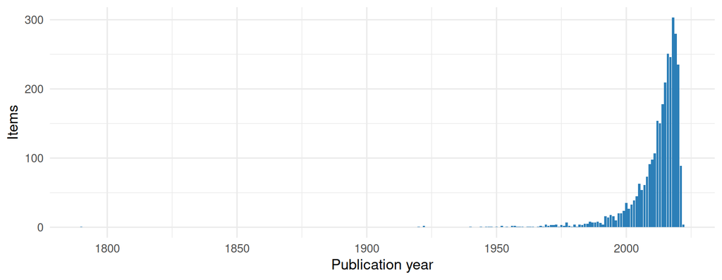

### Types of items

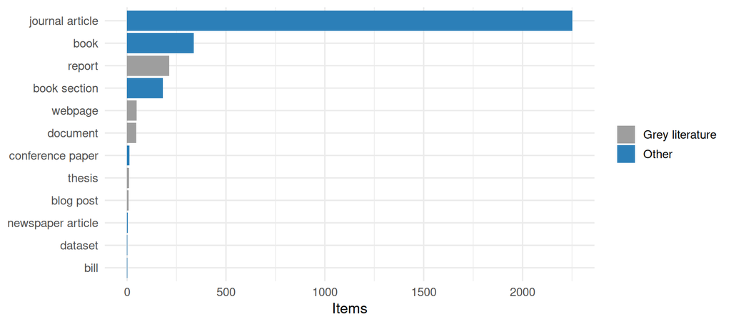

### Open access

Open access status of the publications found in OpenAlex. *Gold* and *diamond*: open in an open access journal; *hybrid*: open in a subscription journal; *green*: an open copy is in a repository; *bronze*: free to read on the publisher’s site; *closed*: not openly available.

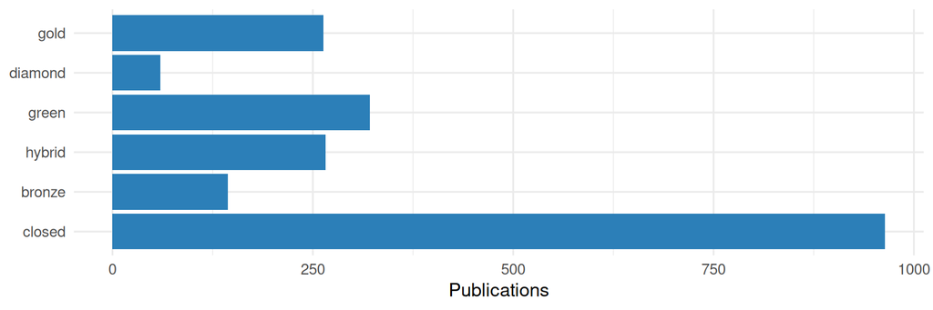

### Most frequent journals

| Journal | Items |
| --- | --- |
| Ecological Economics | 111 |
| Ecosystem Services | 83 |
| Ecology and Society | 70 |
| Current Opinion in Environmental Sustainability | 50 |
| Sustainability Science | 44 |
| Global Environmental Change | 42 |
| Environmental Science & Policy | 32 |
| Sustainability | 31 |
| Proceedings of the National Academy of Sciences | 30 |
| Environmental and Resource Economics | 29 |

### Countries of the authors

Number of publications with at least one author from the country, for the publications found in OpenAlex.

| Country | Publications |
| --- | --- |
| United States | 612 |
| United Kingdom | 456 |
| Germany | 267 |
| Netherlands | 229 |
| Canada | 223 |
| Australia | 202 |
| Sweden | 172 |
| Spain | 161 |
| France | 125 |
| Switzerland | 88 |
| South Africa | 81 |
| Norway | 80 |
| Finland | 71 |
| Italy | 71 |
| Denmark | 67 |

## How the checks work

**NoteDetails of the checks**

#### identifiers

##### DOI coverage (`met_id_doi`)

Number and share of items with a valid DOI, and items whose DOI field is filled but contains no valid DOI. DOIs are extracted with `openalexPro::extract_doi()` and lower cased.

##### ISBN coverage (`met_id_isbn`)

Number and share of items with an ISBN, overall and for the item types which should have one (`book`, `bookSection`).

##### ISSN coverage (`met_id_issn`)

Number and share of items with an ISSN, overall and for the item types which should have one (`journalArticle`, `magazineArticle`).

##### ISSN not in the standard form (`met_id_issn_form`)

Items whose ISSN field is not in the standard form: each ISSN as `1234-567X` (with hyphen, capital X), several separated by “,”. The ISSNs are checked with their check digit. If all are valid, the standard form is proposed; otherwise the item is listed with the ISSNs which are not valid.

##### DOIs in the wrong field (`met_id_doi_misplaced`)

Items with an empty DOI field but a DOI in the `Url` or `Extra` field. These DOIs are not used for the OpenAlex lookup and should be moved to the DOI field.

##### DOIs in the wrong form (`met_id_doi_form`)

Items whose DOI field contains a valid DOI, but not as a bare DOI: as a link (`https://doi.org/10.…`), with a prefix (`doi:`, `DOI`), URL-encoded (`%5B` for `[`) or with spaces or other characters around it. Citation styles add the link themselves, so a link in the DOI field appears twice in a bibliography. The bare DOI is the one recognised by `openalexPro::extract_doi()`, keeping its upper and lower case.

##### Items without identifier (`met_id_none`)

Items with none of DOI, ISBN, ISSN or Url. These items can neither be checked against OpenAlex nor easily be retrieved by readers.

##### DOIs found in OpenAlex for items without a DOI (`met_id_candidates`)

For items without a DOI, OpenAlex was searched by title (see [get_doi_candidates()]). The works found are compared with the item: title (ignoring case and punctuation), year and the surname of the first author. A work is a *likely* match if the titles are (nearly) the same (similarity at least 0.95), the years differ by at most 1 and the first authors have the same surname (year or author are not compared if the item has none), and the title has at least 4 words (short titles like “Zoonoses” are too general). It is a *possible* match if the titles are similar (at least 0.8). All likely and possible works with a DOI are kept, sorted per item, best first. DOIs used by another item in the group are noted (the item would be a duplicate).

#### metadata

##### Filled fields per item type (`met_meta_fields`)

Percentage of items with a filled field, per item type, for the main fields: Title, Author, Publication Year, Publication Title, Publisher, DOI, ISBN, ISSN, Url, Abstract Note and Language. Not every field is expected for every item type, e.g. reports have no Publication Title.

##### Problematic publication years (`met_meta_year`)

Items whose date is missing (`missing`), from whose date Zotero could not derive a year (`unparseable`), or whose year lies in the future (`future`).

##### Duplicate items (`met_meta_duplicates`)

Items which are in the group more than once, identified by the same DOI, or by the same normalised title (lower case, letters and digits only), publication year and first word of the first author.

##### Language not given as a standard code (`met_meta_language`)

Items whose language is not given as a standard language code, i.e. a two-letter ISO 639-1 code, optionally with a region (`en`, `en-US`), but e.g. as a name (`English`), a three-letter code (`eng`) or in a different spelling (`EN`, `en_us`). Citation styles and other tools only recognise the codes. Where the value is recognised, the standard code is proposed, based on the ISO 639-2 list (R package ISOcodes): codes, three-letter codes and the English names of the languages. Other values, e.g. names in the language itself, several languages or other text, are listed without a proposal.

#### openalex_check

##### Zotero DOIs found in OpenAlex (`met_check_found`)

Valid Zotero DOIs which were / were not found in OpenAlex. A DOI which is not found is either not indexed by OpenAlex or wrong.

##### Retracted works (`met_check_retracted`)

Works flagged as retracted by OpenAlex, with the key of the Zotero item(s) with the same DOI.

##### Wrong DOIs (`met_check_mismatch`)

Items whose DOI points in OpenAlex to a work with a different title or year, which usually means that the wrong DOI is attached to the item. An item is flagged when the title similarity (normalised Levenshtein distance) is below 0.8 or the years differ by more than one.

##### Item type agreement (`met_check_type`)

Zotero item type compared with the OpenAlex work type for items with the same DOI.

##### Missing dates found in OpenAlex (`met_check_date`)

Items without a date whose DOI was found in OpenAlex: the publication date in OpenAlex is proposed. OpenAlex gives 1 January when only the year is known, so such dates are proposed as the year only. Items whose DOI points to a different publication are left out.

##### Empty fields found in OpenAlex (`met_check_fill`)

Journal articles with an empty journal, volume, issue or pages field whose DOI was found in OpenAlex with these details: the values in OpenAlex are proposed. The journal is only taken if the publication is in a journal in OpenAlex (not e.g. a repository). Page ranges which end before they start (e.g. `1260-2`, shortened or wrong) are not proposed. Items whose DOI points to a different publication are left out.

##### OpenAlex ID in the Extra field (`met_check_openalex_id`)

Items whose DOI was found in OpenAlex, compared with the OpenAlex ID noted in their Extra field (a line `OpenAlex: W…`). Items without such a line can get it, which links them to OpenAlex for later checks. Items with a different ID are listed for checking: OpenAlex merges records, and the ID of a merged record redirects to the new one. Items whose DOI points to a different publication are left out.

##### OpenAlex ID in the Extra field not valid (`met_check_extra_id`)

Checks the lines `OpenAlex: …` in the Extra field (looked up by [get_extra_ids()]). A line is not valid if - it is not an OpenAlex work ID (`W` and digits), - the item has several lines with different IDs, - the ID is not in OpenAlex (wrong, or merged into another record), or - the work is a different publication: its DOI is not the DOI of the item, or, for items without DOI, its title is not similar (similarity below 0.8, see [title_similarity()]).

#### profile

##### Publication years (`met_prof_year`)

Number of items per publication year, with cumulative counts. Items without a year are counted as `NA`.

##### Open access status (`met_prof_oa`)

OpenAlex open access status (gold, diamond, green, hybrid, bronze, closed) of the works, overall and per publication year.

##### Top journals (`met_prof_journals`)

The 50 most frequent journals, from the Publication Title in Zotero and the source of the primary location in OpenAlex. Ties at rank 50 are included.

##### Author countries (`met_prof_countries`)

Number of works with at least one author affiliated with an institution in a country, per country (ISO 3166-1 alpha-2 codes from OpenAlex).

##### Item types and grey literature (`met_prof_types`)

Number of items per item type (Zotero) or work type (OpenAlex), and the share of grey literature, i.e. reports, theses, dissertations, web pages, documents, presentations, manuscripts, blog posts and preprints.

##### Languages (`met_prof_language`)

Languages as entered, and normalised to two letter codes (lower case, region removed, English spellings mapped to `en`). Inconsistent codes in the language as entered are a quality issue in themselves.

#### maintenance

##### Group activity (`met_maint_activity`)

Items added per month, and items added / modified in the 30 days before the metrics were calculated.

##### Items without tags (`met_maint_tags`)

Items without manual tags. Automatic tags, e.g. keywords imported from the publisher, are ignored.

IPBES Literature Report 0.4.0 · [source code on GitHub](https://github.com/IPBES-Data/IPBES.LiteratureReport) (© IPBES.LiteratureReport authors, [MIT licence](https://opensource.org/license/mit)) · reports and data on this website: [CC0 1.0](https://creativecommons.org/publicdomain/zero/1.0/) (no rights reserved)